# TASK 1_BANK MARKETING CLASSIFICATION & MODEL EXPLAINABILITY

## BANK MARKETING DATASET ANALYSIS

## PROBLEM STATEMENT AND OBJECTIVE

## Problem Statement

Financial institutions invest substantial resources in marketing campaigns aimed at encouraging customers to subscribe to term deposit products. However, contacting every customer can be costly and inefficient. Also, not all customers respond positively to marketing efforts, resulting in wasted resources and reduced campaign efficiency. The challenge is to identify customers who are most likely to subscribe to a term deposit, thus enabling the bank to optimize marketing efforts, improve campaign effectiveness and maximize conversion rates.

## Objective

The objective of this project is to develop predictive classification models capable of identifying customers likely to subscribe to a term deposit. Specifically, the project aims to:

- Explore and understand customer characteristics in the Bank Marketing dataset.
- Clean and preprocess the dataset.
- Properly encode categorical variables for machine learning.
- Train and compare multiple classification models, including Logistic Regression and Random Forest.
- Evaluate model performance using Confusion Matrix, Classification Report, F1 Score, ROC Curve, and ROC-AUC Score.
- Explain at least five individual predictions using SHAP.
- Provide actionable business insights and recommendations based on model results for targeted marketing campaigns.

## DATASET DESCRIPTION

## Dataset Name

Bank Marketing Dataset

## Dataset Overview

The dataset contains information collected from direct marketing campaigns conducted by a Portuguese banking institution. The target variable indicates whether a customer subscribed to a term deposit.

## Key Features

| Feature | Description |
| --- | --- |
| age | Customer age |
| job | Occupation |
| marital | Marital status |
| education | Education level |
| default | Credit default status |
| balance | Average yearly balance |
| housing | Housing loan status |
| loan | Personal loan status |
| contact | Contact communication type |
| duration | Last contact duration |
| campaign | Number of contacts performed |
| pdays | Days since previous campaign |
| previous | Number of previous contacts |
| poutcome | Previous campaign outcome |
| y | Target variable (subscription status) |

## Target Variable

## y

- yes = customer subscribed
- no = customer did not subscribe

## DATASET LOADING

```python
# Import required libraries

# Data Manipulation
import pandas as pd
import numpy as np

# Visualization
import seaborn as sns
import matplotlib.pyplot as plt

# Preprocessing
from sklearn.preprocessing import StandardScaler

# Model Building
from sklearn.model_selection import train_test_split
from sklearn.linear_model import LogisticRegression
from sklearn.ensemble import RandomForestClassifier

# Evaluation
from sklearn.metrics import (
    confusion_matrix,
    classification_report,
    f1_score,
    roc_curve,
    roc_auc_score)

# Ignore warnings
import warnings
warnings.filterwarnings('ignore')
```

```python
# Load dataset
bank = pd.read_csv("bank-marketing.csv", sep=';')
```

```python
# Display dataset shape
print("Dataset Shape:", bank.shape)
```

```
Dataset Shape: (41188, 21)
```

```python
# View First Five Rows
bank.head()
```

|  | age | job | marital | education | default | housing | loan | contact | month | day_of_week | ... | campaign | pdays | previous | poutcome | emp.var.rate | cons.price.idx | cons.conf.idx | euribor3m | nr.employed | y |
| --- | --- | --- | --- | --- | --- | --- | --- | --- | --- | --- | --- | --- | --- | --- | --- | --- | --- | --- | --- | --- | --- |
| 0 | 56 | housemaid | married | basic.4y | no | no | no | telephone | may | mon | ... | 1 | 999 | 0 | nonexistent | 1.1 | 93.994 | -36.4 | 4.857 | 5191.0 | no |
| 1 | 57 | services | married | high.school | unknown | no | no | telephone | may | mon | ... | 1 | 999 | 0 | nonexistent | 1.1 | 93.994 | -36.4 | 4.857 | 5191.0 | no |
| 2 | 37 | services | married | high.school | no | yes | no | telephone | may | mon | ... | 1 | 999 | 0 | nonexistent | 1.1 | 93.994 | -36.4 | 4.857 | 5191.0 | no |
| 3 | 40 | admin. | married | basic.6y | no | no | no | telephone | may | mon | ... | 1 | 999 | 0 | nonexistent | 1.1 | 93.994 | -36.4 | 4.857 | 5191.0 | no |
| 4 | 56 | services | married | high.school | no | no | yes | telephone | may | mon | ... | 1 | 999 | 0 | nonexistent | 1.1 | 93.994 | -36.4 | 4.857 | 5191.0 | no |

5 rows × 21 columns

```python
# View last five rows
bank.tail()
```

|  | age | job | marital | education | default | housing | loan | contact | month | day_of_week | ... | campaign | pdays | previous | poutcome | emp.var.rate | cons.price.idx | cons.conf.idx | euribor3m | nr.employed | y |
| --- | --- | --- | --- | --- | --- | --- | --- | --- | --- | --- | --- | --- | --- | --- | --- | --- | --- | --- | --- | --- | --- |
| 41183 | 73 | retired | married | professional.course | no | yes | no | cellular | nov | fri | ... | 1 | 999 | 0 | nonexistent | -1.1 | 94.767 | -50.8 | 1.028 | 4963.6 | yes |
| 41184 | 46 | blue-collar | married | professional.course | no | no | no | cellular | nov | fri | ... | 1 | 999 | 0 | nonexistent | -1.1 | 94.767 | -50.8 | 1.028 | 4963.6 | no |
| 41185 | 56 | retired | married | university.degree | no | yes | no | cellular | nov | fri | ... | 2 | 999 | 0 | nonexistent | -1.1 | 94.767 | -50.8 | 1.028 | 4963.6 | no |
| 41186 | 44 | technician | married | professional.course | no | no | no | cellular | nov | fri | ... | 1 | 999 | 0 | nonexistent | -1.1 | 94.767 | -50.8 | 1.028 | 4963.6 | yes |
| 41187 | 74 | retired | married | professional.course | no | yes | no | cellular | nov | fri | ... | 3 | 999 | 1 | failure | -1.1 | 94.767 | -50.8 | 1.028 | 4963.6 | no |

5 rows × 21 columns

```python
# Check data types
bank.info()
```

```
<class 'pandas.DataFrame'>
RangeIndex: 41188 entries, 0 to 41187
Data columns (total 21 columns):
 #   Column          Non-Null Count  Dtype
---  ------          --------------  -----
 0   age             41188 non-null  int64
 1   job             41188 non-null  str
 2   marital         41188 non-null  str
 3   education       41188 non-null  str
 4   default         41188 non-null  str
 5   housing         41188 non-null  str
 6   loan            41188 non-null  str
 7   contact         41188 non-null  str
 8   month           41188 non-null  str
 9   day_of_week     41188 non-null  str
 10  duration        41188 non-null  int64
 11  campaign        41188 non-null  int64
 12  pdays           41188 non-null  int64
 13  previous        41188 non-null  int64
 14  poutcome        41188 non-null  str
 15  emp.var.rate    41188 non-null  float64
 16  cons.price.idx  41188 non-null  float64
 17  cons.conf.idx   41188 non-null  float64
 18  euribor3m       41188 non-null  float64
 19  nr.employed     41188 non-null  float64
 20  y               41188 non-null  str
dtypes: float64(5), int64(5), str(11)
memory usage: 9.1 MB
```

```python
# Summary statistics
bank.describe()
```

|  | age | duration | campaign | pdays | previous | emp.var.rate | cons.price.idx | cons.conf.idx | euribor3m | nr.employed |
| --- | --- | --- | --- | --- | --- | --- | --- | --- | --- | --- |
| count | 41188.00000 | 41188.000000 | 41188.000000 | 41188.000000 | 41188.000000 | 41188.000000 | 41188.000000 | 41188.000000 | 41188.000000 | 41188.000000 |
| mean | 40.02406 | 258.285010 | 2.567593 | 962.475454 | 0.172963 | 0.081886 | 93.575664 | -40.502600 | 3.621291 | 5167.035911 |
| std | 10.42125 | 259.279249 | 2.770014 | 186.910907 | 0.494901 | 1.570960 | 0.578840 | 4.628198 | 1.734447 | 72.251528 |
| min | 17.00000 | 0.000000 | 1.000000 | 0.000000 | 0.000000 | -3.400000 | 92.201000 | -50.800000 | 0.634000 | 4963.600000 |
| 25% | 32.00000 | 102.000000 | 1.000000 | 999.000000 | 0.000000 | -1.800000 | 93.075000 | -42.700000 | 1.344000 | 5099.100000 |
| 50% | 38.00000 | 180.000000 | 2.000000 | 999.000000 | 0.000000 | 1.100000 | 93.749000 | -41.800000 | 4.857000 | 5191.000000 |
| 75% | 47.00000 | 319.000000 | 3.000000 | 999.000000 | 0.000000 | 1.400000 | 93.994000 | -36.400000 | 4.961000 | 5228.100000 |
| max | 98.00000 | 4918.000000 | 56.000000 | 999.000000 | 7.000000 | 1.400000 | 94.767000 | -26.900000 | 5.045000 | 5228.100000 |

## DATA CLEANING AND PREPROCESSING

```python
# Check missing values
bank.isnull().sum()
```

```
age               0
job               0
marital           0
education         0
default           0
housing           0
loan              0
contact           0
month             0
day_of_week       0
duration          0
campaign          0
pdays             0
previous          0
poutcome          0
emp.var.rate      0
cons.price.idx    0
cons.conf.idx     0
euribor3m         0
nr.employed       0
y                 0
dtype: int64
```

```python
# Check duplicates
bank.duplicated().sum()
```

```
np.int64(12)
```

```python
# Remove duplicates
bank = bank.drop_duplicates()
print("New Shape:", bank.shape)
```

```
New Shape: (41176, 21)
```

```python
# Check unique categories
for col in bank.select_dtypes(include='object').columns:
    print("\n", col)
    print(bank[col].unique())
```

```
 job
<ArrowStringArray>
[    'housemaid',      'services',        'admin.',   'blue-collar',
    'technician',       'retired',    'management',    'unemployed',
 'self-employed',       'unknown',  'entrepreneur',       'student']
Length: 12, dtype: str

 marital
<ArrowStringArray>
['married', 'single', 'divorced', 'unknown']
Length: 4, dtype: str

 education
<ArrowStringArray>
[           'basic.4y',         'high.school',            'basic.6y',
            'basic.9y', 'professional.course',             'unknown',
   'university.degree',          'illiterate']
Length: 8, dtype: str

 default
<ArrowStringArray>
['no', 'unknown', 'yes']
Length: 3, dtype: str

 housing
<ArrowStringArray>
['no', 'yes', 'unknown']
Length: 3, dtype: str

 loan
<ArrowStringArray>
['no', 'yes', 'unknown']
Length: 3, dtype: str

 contact
<ArrowStringArray>
['telephone', 'cellular']
Length: 2, dtype: str

 month
<ArrowStringArray>
['may', 'jun', 'jul', 'aug', 'oct', 'nov', 'dec', 'mar', 'apr', 'sep']
Length: 10, dtype: str

 day_of_week
<ArrowStringArray>
['mon', 'tue', 'wed', 'thu', 'fri']
Length: 5, dtype: str

 poutcome
<ArrowStringArray>
['nonexistent', 'failure', 'success']
Length: 3, dtype: str

 y
<ArrowStringArray>
['no', 'yes']
Length: 2, dtype: str
```

## EXPLORATORY DATA ANALYSIS (EDA)

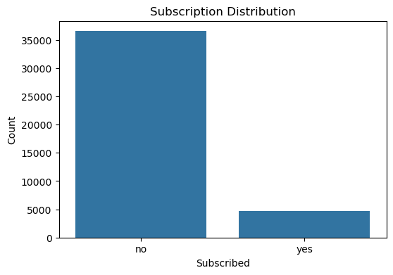

```python
# Target variable distribution
plt.figure(figsize=(6,4))

sns.countplot(x='y', data=bank)

plt.title("Subscription Distribution")
plt.xlabel("Subscribed")
plt.ylabel("Count")

plt.show()
```

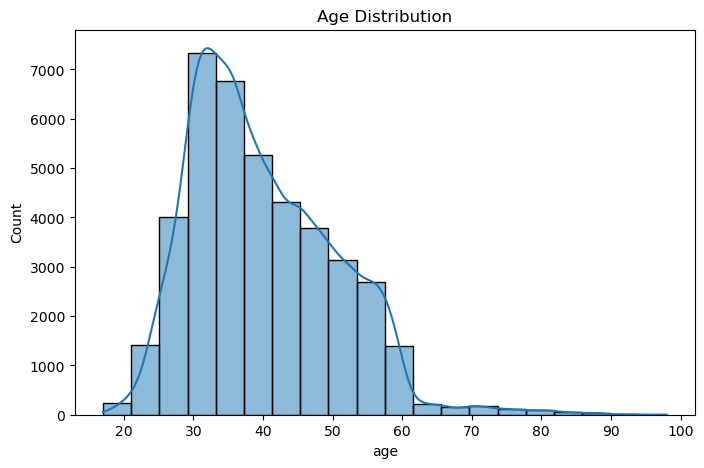

```python
# Age distribution
plt.figure(figsize=(8,5))

sns.histplot(bank['age'],
             bins=20,
             kde=True)

plt.title("Age Distribution")

plt.show()
```

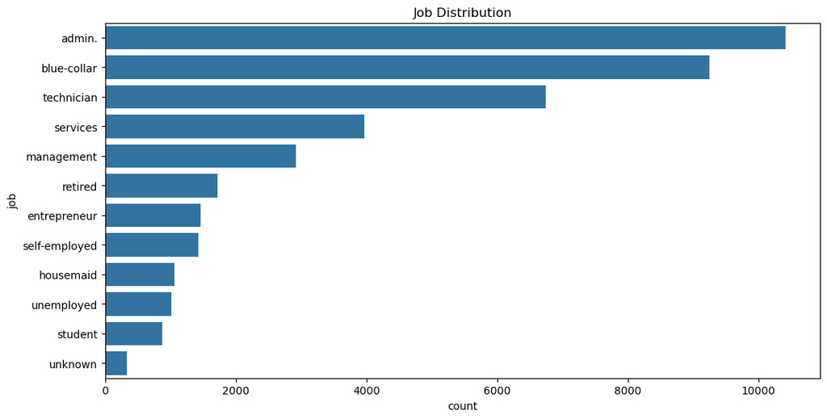

```python
# Job distribution
plt.figure(figsize=(12,6))

sns.countplot(y='job',
              data=bank,
              order=bank['job'].value_counts().index)

plt.title("Job Distribution")

plt.show()
```

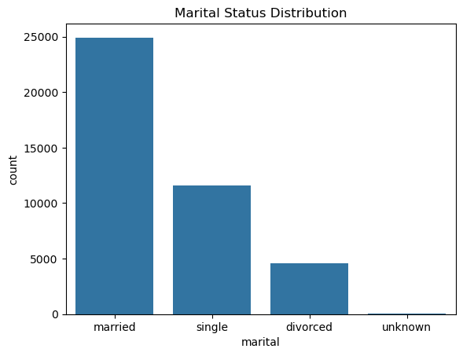

```python
# Marital status distribution
sns.countplot(x='marital',
              data=bank)

plt.title("Marital Status Distribution")

plt.show()
```

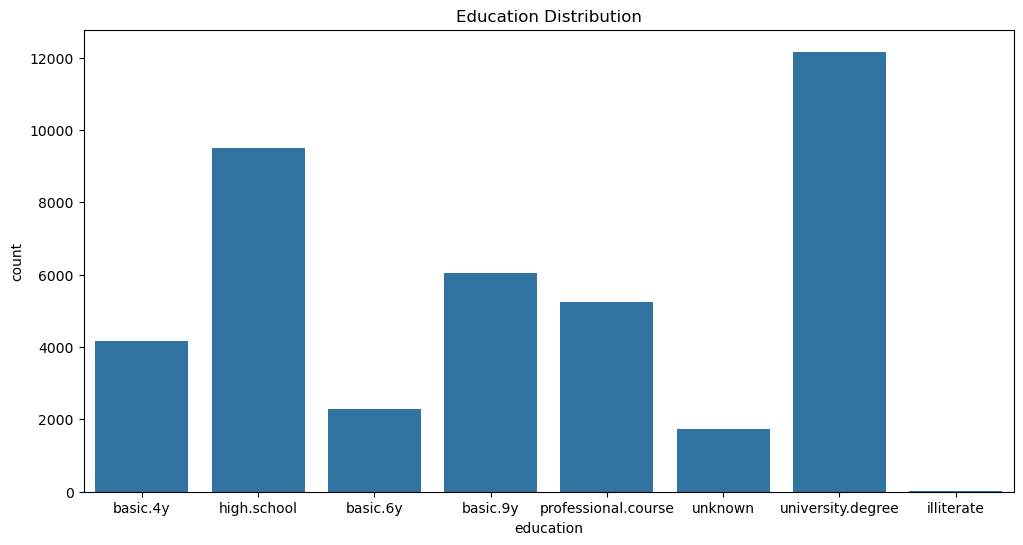

```python
# Education distribution
plt.figure(figsize=(12,6))

sns.countplot(x='education',
              data=bank)

plt.title("Education Distribution")

plt.show()
```

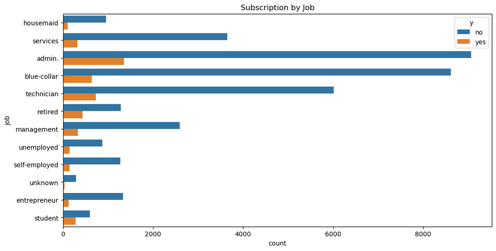

```python
# Subscription by Job
plt.figure(figsize=(12,6))

sns.countplot(y='job',
              hue='y',
              data=bank)

plt.title("Subscription by Job")

plt.show()
```

```python
# Correlation Heatmap
# Select numerical columns
numerical_cols = bank.select_dtypes(include=np.number)
```

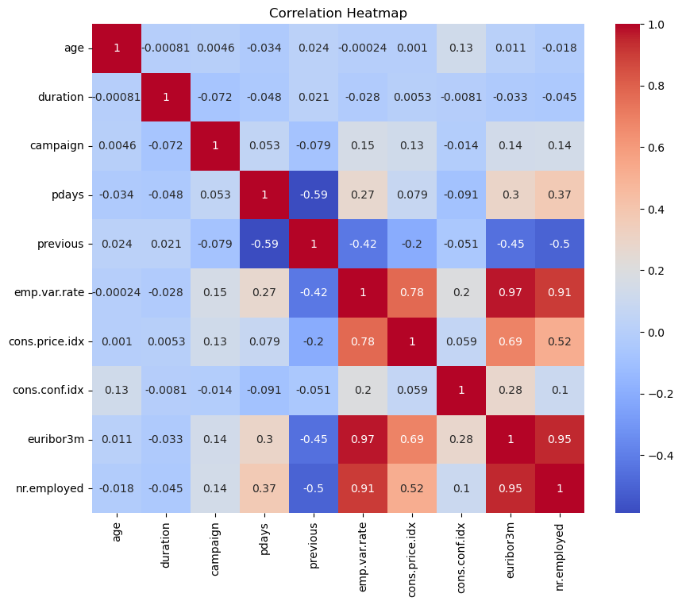

```python
# Plot heatmap
plt.figure(figsize=(10,8))

sns.heatmap(numerical_cols.corr(),
            annot=True,
            cmap='coolwarm')

plt.title("Correlation Heatmap")

plt.show()
```

## FEATURE ENGINEERING AND ENCODING

```python
# Encode target variable
bank['y'] = bank['y'].map({'no':0,
                           'yes':1})
```

```python
# One-Hot encode categorical variables
bank_encoded = pd.get_dummies(bank,
                              drop_first=True)
```

```python
# Separate features and target
X = bank_encoded.drop('y', axis=1)

y = bank_encoded['y']
```

```python
# Train-test split
X_train, X_test, y_train, y_test = train_test_split(X,
                                                    y,
                                                    test_size=0.20,
                                                    random_state=42,
                                                    stratify=y)
```

```python
# Feature scaling
scaler = StandardScaler()

X_train_scaled = scaler.fit_transform(X_train)

X_test_scaled = scaler.transform(X_test)
```

## MODEL BUILDING

## Model 1: Logistic Regression

```python
# Train model
lr_model = LogisticRegression(max_iter=1000)

lr_model.fit(X_train_scaled,
             y_train)
```

```
LogisticRegression(max_iter=1000)
```

```python
# Predictions
lr_pred = lr_model.predict(X_test_scaled)

lr_prob = lr_model.predict_proba(X_test_scaled)[:,1]
```

## Model 2: Random Forest

```python
# Train model
rf_model = RandomForestClassifier(n_estimators=200,
                                  random_state=42)

rf_model.fit(X_train,
             y_train)
```

```
RandomForestClassifier(n_estimators=200, random_state=42)
```

```python
# Predictions
rf_pred = rf_model.predict(X_test)

rf_prob = rf_model.predict_proba(X_test)[:,1]
```

## MODEL EVALUATION

## Logistic Regression Evaluation

```python
# Classification report
print(classification_report(y_test,
                            lr_pred))
```

```
              precision    recall  f1-score   support

           0       0.93      0.97      0.95      7308
           1       0.65      0.42      0.51       928

    accuracy                           0.91      8236
   macro avg       0.79      0.70      0.73      8236
weighted avg       0.90      0.91      0.90      8236
```

```python
# F1 Score
lr_f1 = f1_score(y_test,
                 lr_pred)

print("Logistic Regression F1 Score:", lr_f1)
```

```
Logistic Regression F1 Score: 0.51208360548661
```

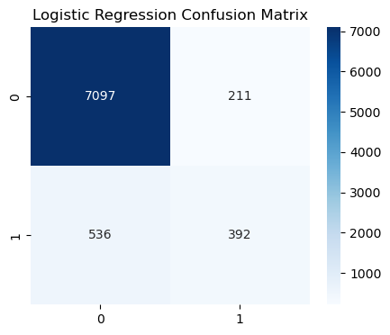

```python
# Confusion Matrix
cm_lr = confusion_matrix(y_test,
                         lr_pred)

plt.figure(figsize=(5,4))

sns.heatmap(cm_lr,
            annot=True,
            fmt='d',
            cmap='Blues')

plt.title("Logistic Regression Confusion Matrix")

plt.show()
```

## Random Forest Evaluation

```python
# Classification Report
print(classification_report(y_test,
                            rf_pred))
```

```
              precision    recall  f1-score   support

           0       0.94      0.97      0.95      7308
           1       0.66      0.49      0.56       928

    accuracy                           0.91      8236
   macro avg       0.80      0.73      0.76      8236
weighted avg       0.91      0.91      0.91      8236
```

```python
# F1 Score
rf_f1 = f1_score(y_test,
                 rf_pred)

print("Random Forest F1 Score:", rf_f1)
```

```
Random Forest F1 Score: 0.5587144622991347
```

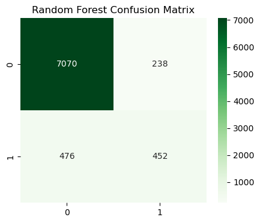

```python
# Confusion Matrix
cm_rf = confusion_matrix(y_test,
                         rf_pred)

plt.figure(figsize=(5,4))

sns.heatmap(cm_rf,
            annot=True,
            fmt='d',
            cmap='Greens')

plt.title("Random Forest Confusion Matrix")

plt.show()
```

## ROC Curve

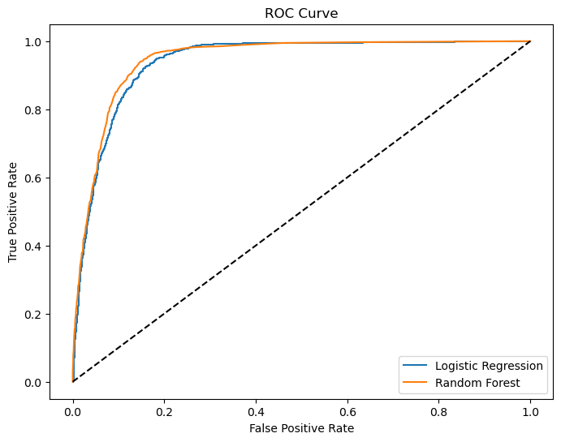

```python
fpr_lr, tpr_lr, _ = roc_curve(y_test,
                              lr_prob)

fpr_rf, tpr_rf, _ = roc_curve(y_test,
                              rf_prob)

plt.figure(figsize=(8,6))

plt.plot(fpr_lr,
         tpr_lr,
         label="Logistic Regression")

plt.plot(fpr_rf,
         tpr_rf,
         label="Random Forest")

plt.plot([0,1],[0,1],'k--')

plt.xlabel("False Positive Rate")
plt.ylabel("True Positive Rate")

plt.title("ROC Curve")

plt.legend()

plt.show()
```

## ROC-AUC Scores

```python
lr_auc = roc_auc_score(y_test,
                       lr_prob)

rf_auc = roc_auc_score(y_test,
                       rf_prob)

print("Logistic Regression AUC:", lr_auc)

print("Random Forest AUC:", rf_auc)
```

```
Logistic Regression AUC: 0.9389872105203556
Random Forest AUC: 0.9457779352575355
```

## Model Comparison Table

```python
comparison = pd.DataFrame({"Model":["Logistic Regression",
                                    "Random Forest"],

                           "F1 Score":[lr_f1,
                                       rf_f1],

                           "ROC-AUC":[lr_auc,
                                      rf_auc]})

comparison
```

|  | Model | F1 Score | ROC-AUC |
| --- | --- | --- | --- |
| 0 | Logistic Regression | 0.512084 | 0.938987 |
| 1 | Random Forest | 0.558714 | 0.945778 |

## FEATURE IMPORTANCE

```python
feature_importance = pd.DataFrame({"Feature":X.columns,
                                   "Importance":rf_model.feature_importances_})

feature_importance = feature_importance.sort_values(by="Importance",
                                                    ascending=False)

feature_importance.head(10)
```

|  | Feature | Importance |
| --- | --- | --- |
| 1 | duration | 0.299735 |
| 8 | euribor3m | 0.092817 |
| 0 | age | 0.086726 |
| 9 | nr.employed | 0.056066 |
| 2 | campaign | 0.041926 |
| 3 | pdays | 0.031444 |
| 7 | cons.conf.idx | 0.027190 |
| 5 | emp.var.rate | 0.024193 |
| 6 | cons.price.idx | 0.023870 |
| 52 | poutcome_success | 0.021736 |

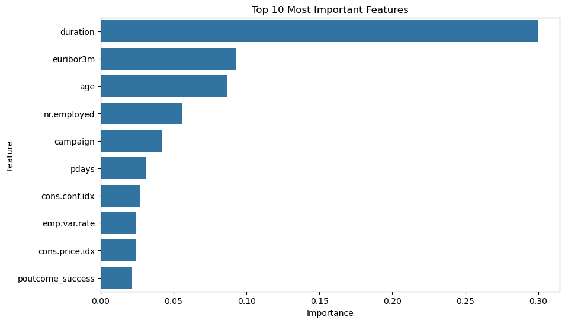

```python
# Visualization
top10 = feature_importance.head(10)

plt.figure(figsize=(10,6))

sns.barplot(x="Importance",
            y="Feature",
            data=top10)

plt.title("Top 10 Most Important Features")

plt.show()
```

## SHAP MODEL EXPLAINABILITY

```python
# Install SHAP
!pip install shap
```

```python
# Import SHAP
import shap
```

```python
# Create explainer
explainer = shap.TreeExplainer(rf_model)
```

```python
# Select 5 test records
sample = X_test.iloc[:5]
```

```python
# Generate SHAP values
shap_values = explainer.shap_values(sample)
```

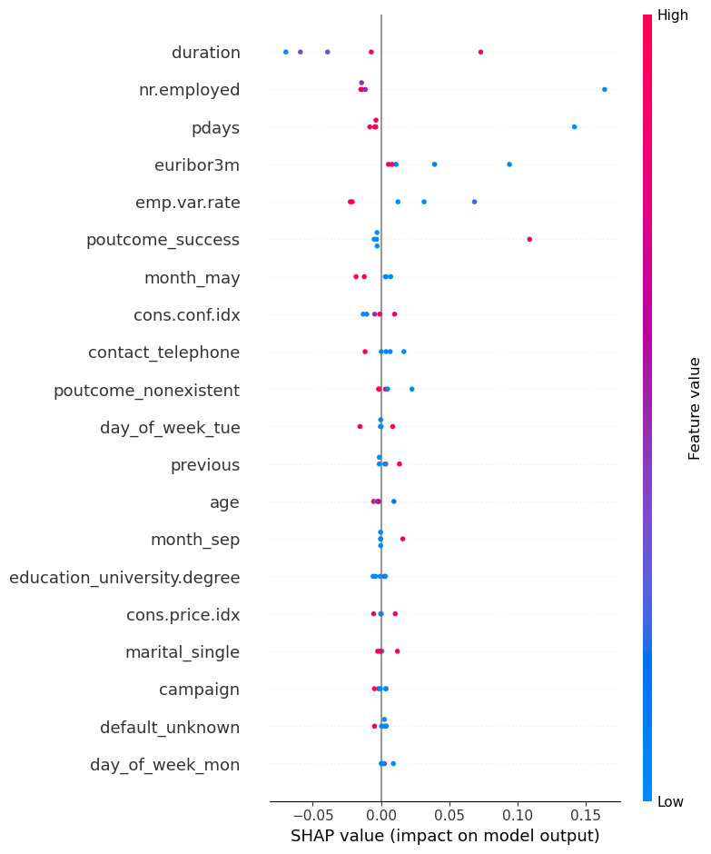

```python
# SHAP Summary Plot
shap.summary_plot(shap_values[:, :, 1],
                  sample)
```

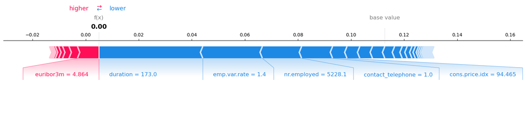

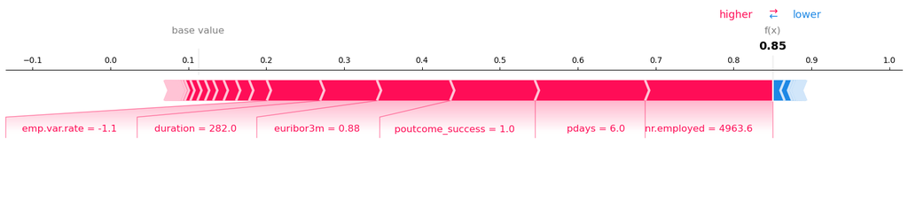

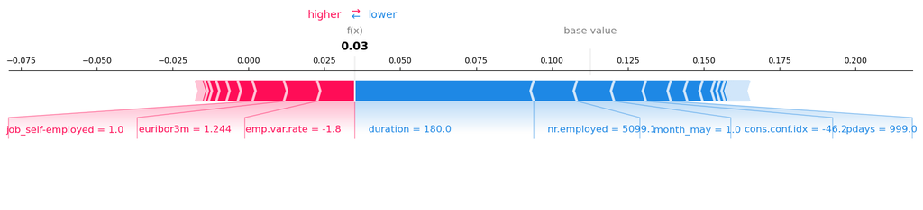

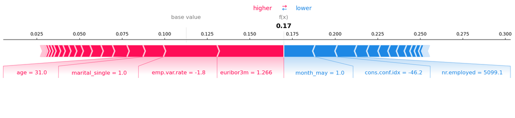

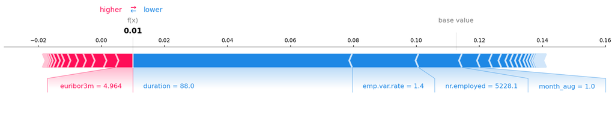

```python
# SHAP Predictions
for i in range(5):
    shap.force_plot(explainer.expected_value[1],
                    shap_values[i, :, 1],
                    sample.iloc[i],
                    matplotlib=True)
```

- Positive campaign-related variables increased subscription probability.
- Certain demographic characteristics reduced confidence in the positive prediction.
- The model ultimately classified the customer as likely to subscribe due to stronger positive influences.

## Overall SHAP Interpretation

The SHAP analysis confirms that:

- Contact duration is the most influential feature.
- Previous successful campaign outcomes strongly increase subscription probability.
- Customer engagement history contributes more to prediction decisions than demographic attributes.
- The model's decisions are transparent and consistent with the business objective of identifying likely subscribers.

## 2. Model Performance

- Both Logistic Regression and Random Forest performed well in predicting subscription outcomes.
- Random Forest achieved superior performance due to its ability to capture complex, non-linear relationships between customer attributes and subscription behavior.
- The ROC curve indicates strong discriminatory power, demonstrating that the model effectively distinguishes between subscribers and non-subscribers.

## Recommendations

1. Prioritize customers with previous successful campaign interactions.
2. Increase focus on customers who engage positively during calls.
3. Use predictive scores to prioritize outreach efforts.
4. Allocate marketing resources toward customer segments with historically higher conversion rates.
5. Incorporate model predictions into campaign planning to improve efficiency and reduce marketing costs.

## CONCLUSION

This project developed machine learning models to predict customer subscription to term deposit products using the Bank Marketing dataset.

After data preprocessing, feature encoding, and model training, Logistic Regression and Random Forest models were evaluated using F1 Score, Confusion Matrix, ROC Curve, and ROC-AUC metrics. Random Forest achieved superior predictive performance by capturing complex relationships among customer attributes.